# Estudio variabilidad estructural proteica

30/01/2016

## Conjuntos de proteinas

### Conjunto teorico

130 mutantes de 5gst (217 sitios) simuladas con el modelo mutacional LFENM con ANM *R0* = 12 y *Fmax* = 2 (solo para LFENM). Para determinar que sitios mutar, se alineo 5gst con cada una de las proteinas del conjunto, se obtuvieron los indices de los sitios alineados pero mutados y se simularon 10 mutantes por cada par de proteinas, obteniendose un total de 130 mutantes. Luego, para el analisis, se tomaron como alineados los sitios alineados de 5gst para cada par de proteinas.

### Conjunto experimental

13 proteinas de la familia de gluts. Las proteinas tienen un promedio de identidad secuencial de 44%. El core del alineamiento de la familia es de 200 sitios.

La caracterizacion del conjunto experimental se muestra a continuacion:

```
##    pdbid nsites naligned identity       MSD
## 1   1hna    217      217 75.57604 0.8357275
## 2  1gsua    217      217 60.82949 0.8591810
## 3   1gta    218      212 43.39623 2.4082283
## 4  2fhea    216      212 47.16981 1.8968747
## 5   1fhe    214      212 47.64151 2.3328315
## 6  2gsra    207      202 31.68317 3.9167222
## 7  1glpa    209      202 30.19802 3.9327059
## 8  17gsa    210      202 30.19802 3.9573604
## 9  1guha    221      209 20.09569 6.0684256
## 10 1guka    215      208 21.63462 6.6429255
## 11 1gula    217      209 19.61722 6.8280139
## 12 1gtua    217      217 79.26267 0.3018244
## 13 3gtub    224      217 67.74194 0.9264465
```

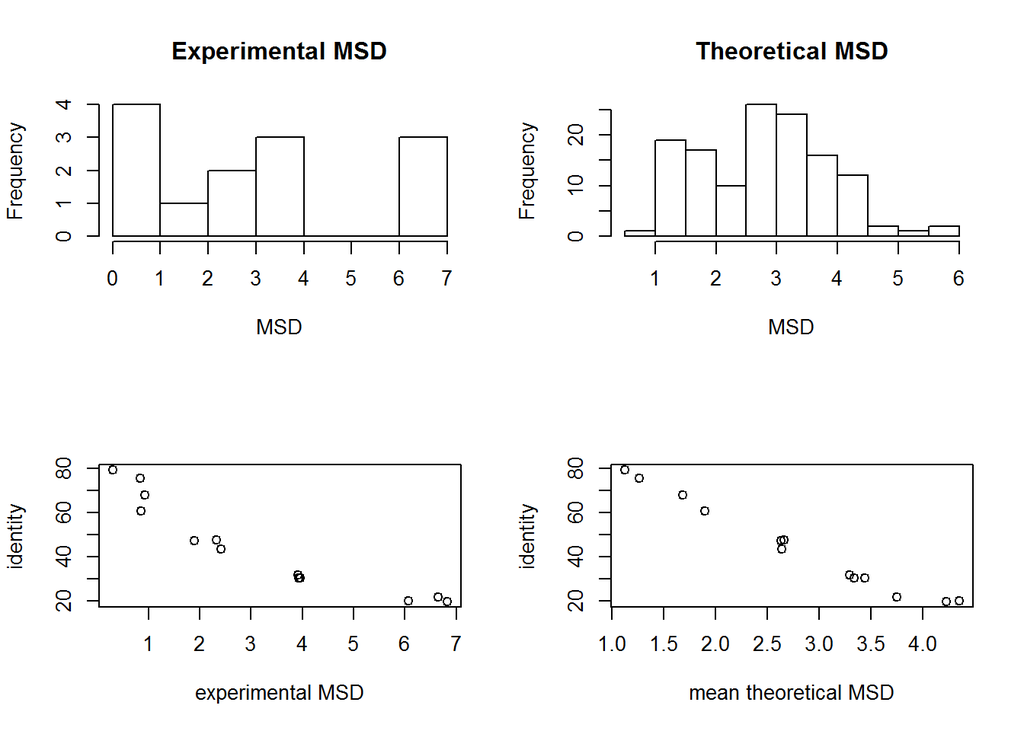

## Comparaciones

### RHO y AUC

Las distribuciones de *auc* y *rho* para cada conjunto se muestran a continuacion (azul= teorico, rojo = experimental)

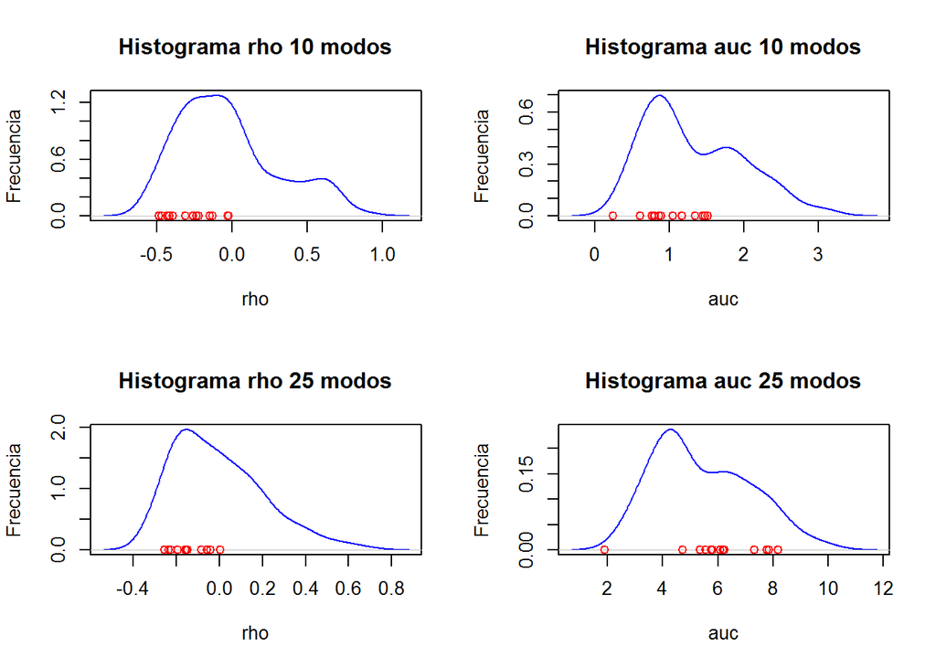

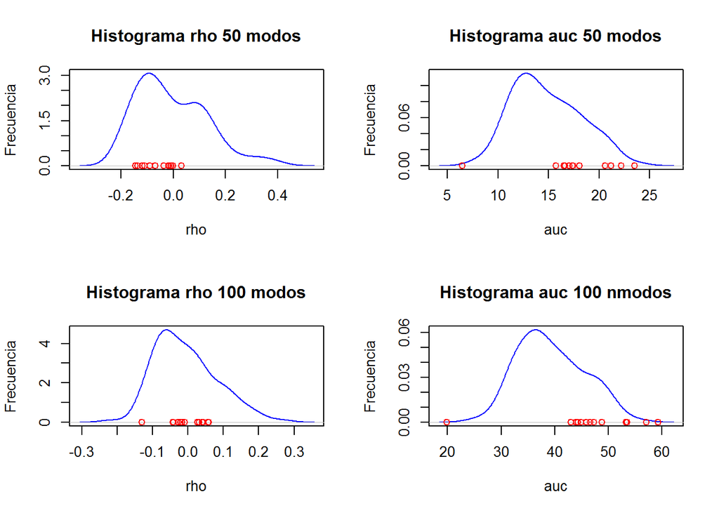

## Pn y Qn

Las distribuciones de *Pn* y *Qn* de los conjuntos son las siguientes:

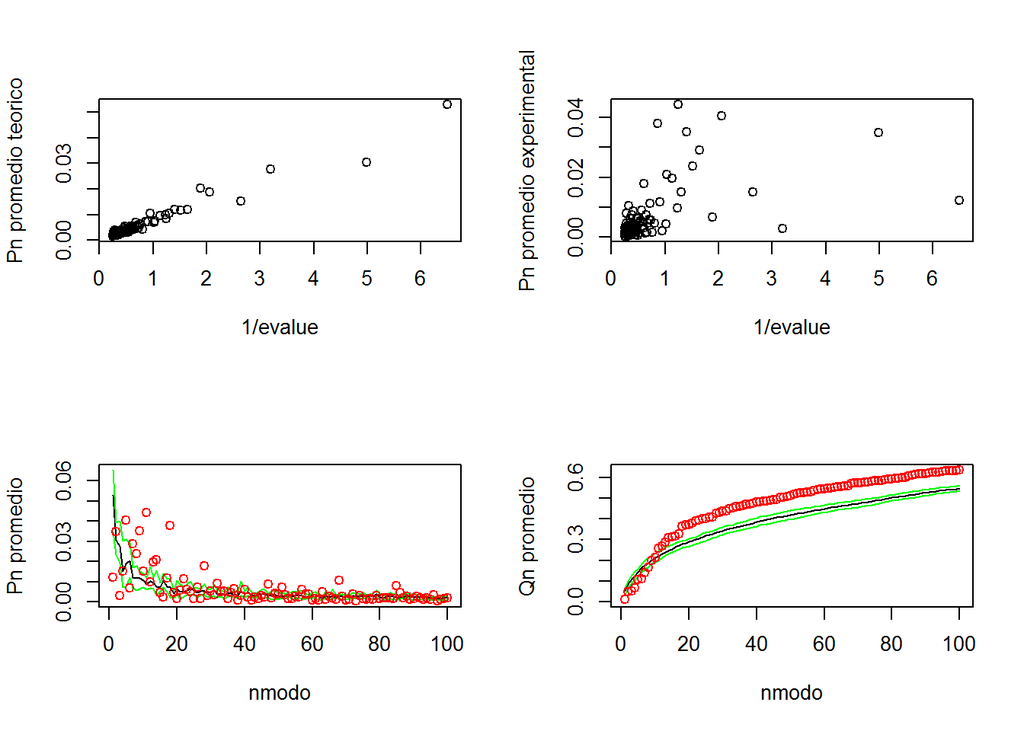

Negro: Teorico Rojo: Experimental Verdes: Cuartiles 0.05 y 0.95 de 10 grupos de 13 mutantes teoricas.